# ABCDv5.1 Baseline Scores

# Elastic net linear regression using ‘glmnet’

Predictors identified from quantitative reviews of adolescent MDD risk factors in baseline ABCD data are included in the model, along with interactions with gender (parent-reported child gender identity). I will also fit a model with interactions with birth sex too as a sensitivity analysis.

## CBCL DSM5-oriented depression subscale

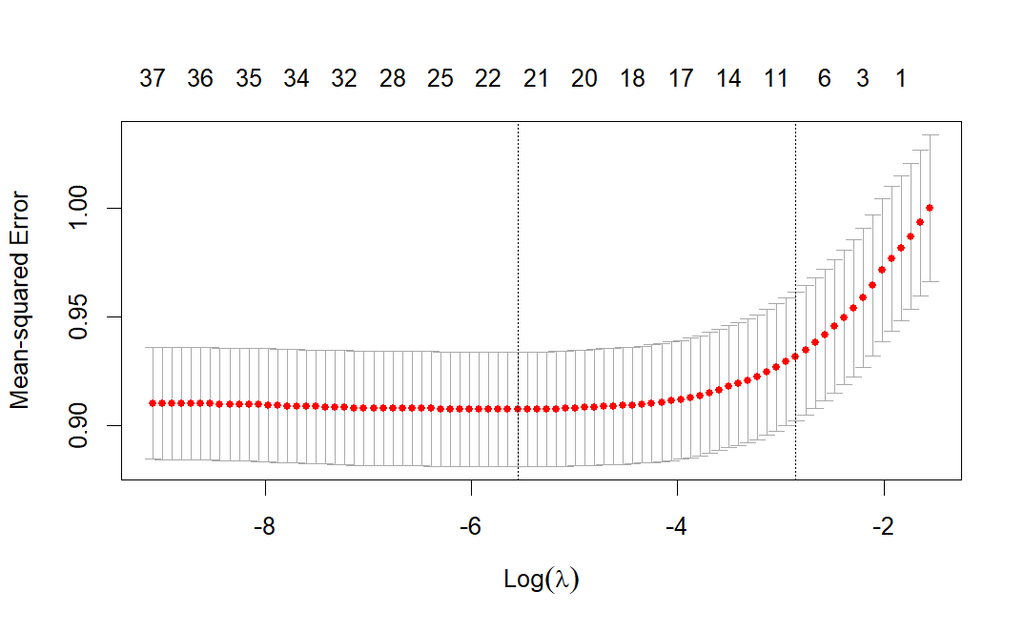

| Criteria | Lambda | MSE | SE | RMSE | Nonzero |
| --- | --- | --- | --- | --- | --- |
| min | 0.004 | 0.907 | 0.026 | 0.953 | 22 |
| 1se | 0.058 | 0.932 | 0.030 | 0.965 | 9 |

### Fit statistics

| Sample | Lambda | MSE | RMSE | MAE |
| --- | --- | --- | --- | --- |
| training | min | 0.897 | 0.947 | 0.666 |
| training | 1se | 0.927 | 0.963 | 0.674 |
| test | min | 0.888 | 0.942 | 0.656 |
| test | 1se | 0.888 | 0.942 | 0.656 |

### Plot predictions

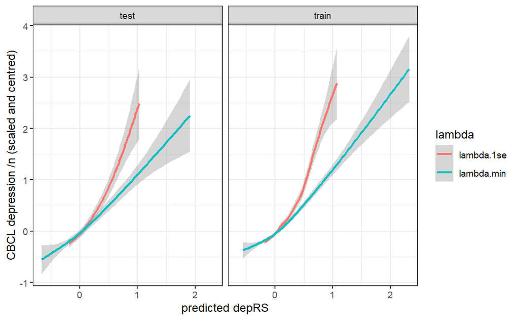

## CBCL internalising subscale

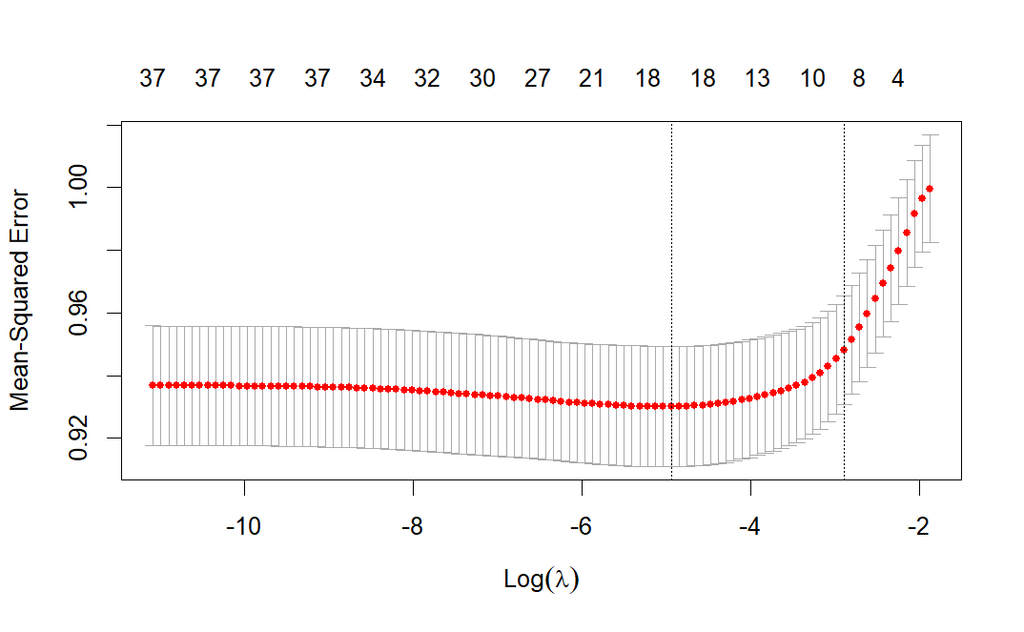

| Criteria | Lambda | MSE | SE | RMSE | Nonzero |
| --- | --- | --- | --- | --- | --- |
| min | 0.007 | 0.930 | 0.019 | 0.964 | 22 |
| 1se | 0.055 | 0.948 | 0.017 | 0.974 | 9 |

### Fit statistics

| Sample | Lambda | MSE | RMSE | MAE |
| --- | --- | --- | --- | --- |
| training | min | 0.923 | 0.961 | 0.708 |
| training | 1se | 0.943 | 0.971 | 0.716 |
| test | min | 0.901 | 0.949 | 0.660 |
| test | 1se | 0.901 | 0.949 | 0.660 |

### Plot predictions

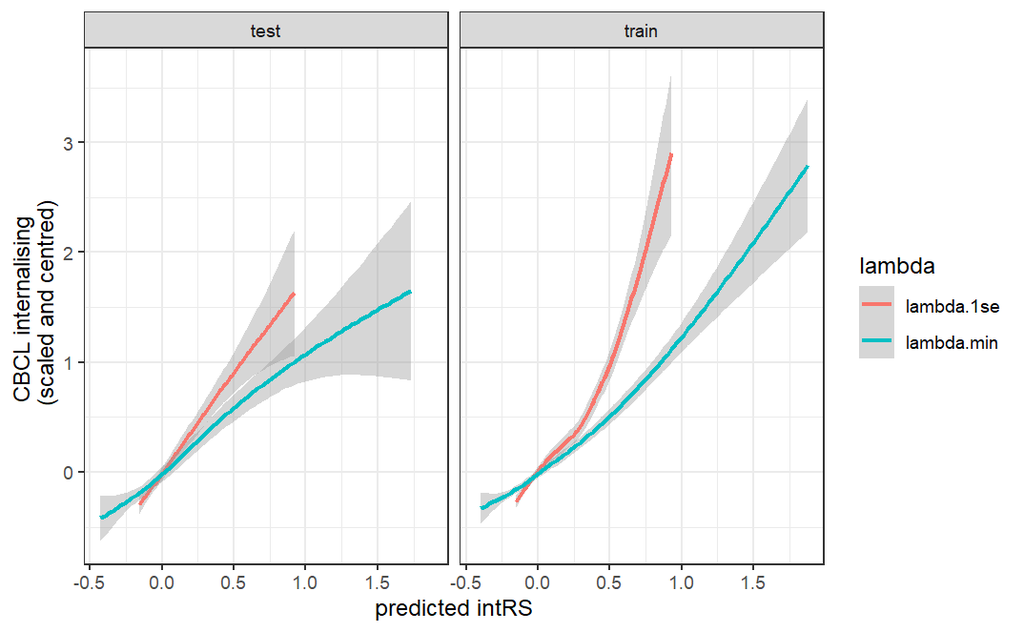

## Coefficients

beta.min = coefficients for lambda value that produces minimum mean cross-validated error beta.1se = coefficients for lambda value that produces the most regularized model while keeping the cross-validated error within one standard error of the minimum.

| predictor | dep_beta.min | dep_beta.1se | int_beta.min | int_beta.1se |
| --- | --- | --- | --- | --- |
| (Intercept) | -3.240 | -1.175 | -2.829 | -1.126 |
| tobacco_puff | 0.181 | 0.000 | 0.244 | 0.000 |
| weightcontrol_ksads | 0.476 | 0.172 | 0.447 | 0.206 |
| witness_comm_violence | 0.073 | 0.000 | 0.000 | 0.000 |
| death_loved_one | 0.088 | 0.000 | 0.131 | 0.056 |
| witness_dv | 0.302 | 0.228 | 0.337 | 0.262 |
| s_abuse | 0.297 | 0.078 | 0.354 | 0.142 |
| p_abuse | 0.321 | 0.049 | 0.042 | 0.000 |
| emot_abuse | 0.424 | 0.122 | 0.366 | 0.067 |
| serious_accident | 0.131 | 0.000 | 0.191 | 0.058 |
| sleep_hrs | 0.281 | 0.161 | 0.095 | 0.051 |
| bmi | -0.019 | 0.000 | 0.000 | 0.000 |
| needed_food | 0.365 | 0.213 | 0.309 | 0.187 |
| income | 0.000 | 0.000 | 0.000 | 0.000 |
| parent_ed | 0.051 | 0.000 | 0.038 | 0.000 |
| gender | 0.000 | 0.000 | 0.000 | 0.000 |
| area_depriv | 0.000 | 0.000 | 0.000 | 0.000 |
| comm_safety | -0.049 | -0.027 | -0.048 | -0.048 |
| days_active | -0.033 | 0.000 | -0.016 | 0.000 |
| agemths | 0.014 | 0.000 | 0.000 | 0.000 |
| tobacco_puff_gender | 0.000 | 0.000 | 0.000 | 0.000 |
| weightcontrol_ksads_gender | 0.000 | 0.000 | 0.009 | 0.000 |
| witness_comm_violence_gender | 0.000 | 0.000 | 0.000 | 0.000 |
| death_loved_one_gender | 0.000 | 0.000 | 0.000 | 0.000 |
| witness_dv_gender | 0.000 | 0.000 | 0.000 | 0.000 |
| s_abuse_gender | 0.000 | 0.000 | 0.000 | 0.000 |
| p_abuse_gender | 0.000 | 0.000 | 0.000 | 0.000 |
| emot_abuse_gender | -0.027 | 0.000 | 0.000 | 0.000 |
| serious_accident_gender | 0.000 | 0.000 | 0.000 | 0.000 |
| sleep_hrs_gender | -0.045 | 0.000 | 0.000 | 0.000 |
| bmi_gender | 0.000 | 0.000 | 0.000 | 0.000 |
| needed_food_gender | 0.000 | 0.000 | 0.000 | 0.000 |
| income_gender | 0.000 | 0.000 | 0.000 | 0.000 |
| parent_ed_gender | 0.000 | 0.000 | 0.001 | 0.000 |
| area_depriv_gender | -0.031 | 0.000 | -0.015 | 0.000 |
| comm_safety_gender | -0.018 | 0.000 | -0.027 | -0.002 |
| days_active_gender | 0.000 | 0.000 | 0.000 | 0.000 |
| agemths_gender | -0.012 | 0.000 | -0.005 | 0.000 |

### beta.min

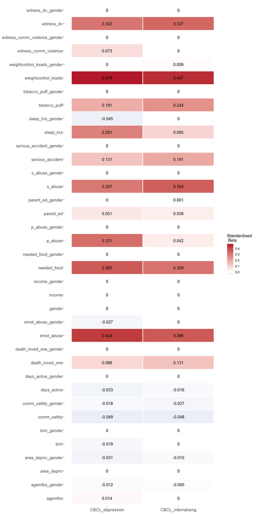

### beta.1se

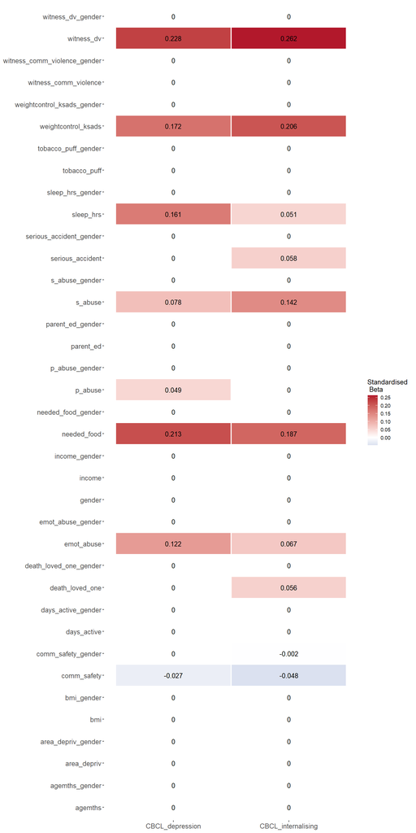

## Non-zero coefficients

### beta.min

|  | preds | beta.min | beta.1se | out |
| --- | --- | --- | --- | --- |
| 39 | weightcontrol_ksads | 0.4757783 | 0.1719840 | CBCL_depression |
| 3 | weightcontrol_ksads | 0.4470135 | 0.2061079 | CBCL_internalising |
| 91 | emot_abuse | 0.4239298 | 0.1218685 | CBCL_depression |
| 9 | emot_abuse | 0.3657381 | 0.0668103 | CBCL_internalising |
| 131 | needed_food | 0.3653713 | 0.2132951 | CBCL_depression |
| 7 | s_abuse | 0.3539089 | 0.1419666 | CBCL_internalising |
| 6 | witness_dv | 0.3369835 | 0.2620152 | CBCL_internalising |
| 81 | p_abuse | 0.3212705 | 0.0489293 | CBCL_depression |
| 13 | needed_food | 0.3085672 | 0.1873661 | CBCL_internalising |
| 61 | witness_dv | 0.3018718 | 0.2278328 | CBCL_depression |
| 71 | s_abuse | 0.2972856 | 0.0783552 | CBCL_depression |
| 111 | sleep_hrs | 0.2812798 | 0.1613062 | CBCL_depression |
| 2 | tobacco_puff | 0.2440664 | 0.0000000 | CBCL_internalising |
| 10 | serious_accident | 0.1907897 | 0.0575381 | CBCL_internalising |
| 210 | tobacco_puff | 0.1805472 | 0.0000000 | CBCL_depression |
| 5 | death_loved_one | 0.1309123 | 0.0562046 | CBCL_internalising |
| 101 | serious_accident | 0.1306486 | 0.0000000 | CBCL_depression |
| 11 | sleep_hrs | 0.0945100 | 0.0512382 | CBCL_internalising |
| 51 | death_loved_one | 0.0880807 | 0.0000000 | CBCL_depression |
| 41 | witness_comm_violence | 0.0727096 | 0.0000000 | CBCL_depression |
| 151 | parent_ed | 0.0512640 | 0.0000000 | CBCL_depression |
| 8 | p_abuse | 0.0424423 | 0.0000000 | CBCL_internalising |
| 15 | parent_ed | 0.0378085 | 0.0000000 | CBCL_internalising |
| 201 | agemths | 0.0137067 | 0.0000000 | CBCL_depression |
| 22 | weightcontrol_ksads_gender | 0.0093294 | 0.0000000 | CBCL_internalising |
| 34 | parent_ed_gender | 0.0008840 | 0.0000000 | CBCL_internalising |
| 38 | agemths_gender | -0.0047293 | 0.0000000 | CBCL_internalising |
| 381 | agemths_gender | -0.0124082 | 0.0000000 | CBCL_depression |
| 35 | area_depriv_gender | -0.0146918 | 0.0000000 | CBCL_internalising |
| 19 | days_active | -0.0160066 | 0.0000000 | CBCL_internalising |
| 361 | comm_safety_gender | -0.0183105 | 0.0000000 | CBCL_depression |
| 121 | bmi | -0.0190751 | 0.0000000 | CBCL_depression |
| 36 | comm_safety_gender | -0.0266220 | -0.0015596 | CBCL_internalising |
| 281 | emot_abuse_gender | -0.0271226 | 0.0000000 | CBCL_depression |
| 351 | area_depriv_gender | -0.0307677 | 0.0000000 | CBCL_depression |
| 191 | days_active | -0.0327217 | 0.0000000 | CBCL_depression |
| 301 | sleep_hrs_gender | -0.0446007 | 0.0000000 | CBCL_depression |
| 18 | comm_safety | -0.0479511 | -0.0481871 | CBCL_internalising |
| 181 | comm_safety | -0.0487609 | -0.0272559 | CBCL_depression |

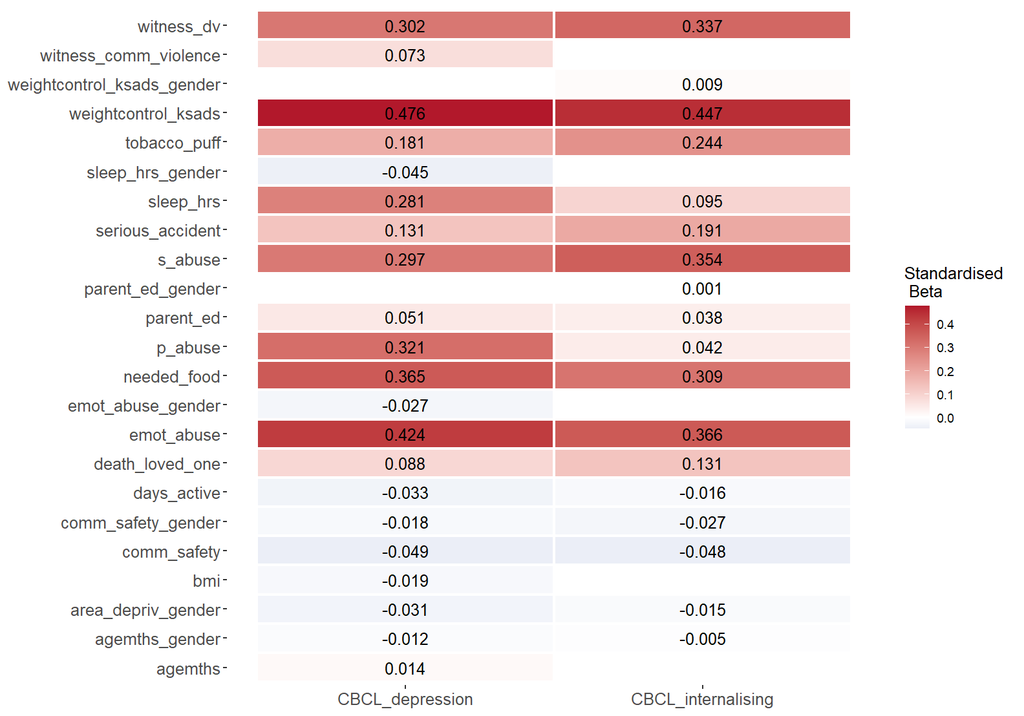

### beta.1se

|  | preds | beta.min | beta.1se | out |
| --- | --- | --- | --- | --- |
| 6 | witness_dv | 0.3369835 | 0.2620152 | CBCL_internalising |
| 61 | witness_dv | 0.3018718 | 0.2278328 | CBCL_depression |
| 131 | needed_food | 0.3653713 | 0.2132951 | CBCL_depression |
| 3 | weightcontrol_ksads | 0.4470135 | 0.2061079 | CBCL_internalising |
| 13 | needed_food | 0.3085672 | 0.1873661 | CBCL_internalising |
| 39 | weightcontrol_ksads | 0.4757783 | 0.1719840 | CBCL_depression |
| 111 | sleep_hrs | 0.2812798 | 0.1613062 | CBCL_depression |
| 7 | s_abuse | 0.3539089 | 0.1419666 | CBCL_internalising |
| 91 | emot_abuse | 0.4239298 | 0.1218685 | CBCL_depression |
| 71 | s_abuse | 0.2972856 | 0.0783552 | CBCL_depression |
| 9 | emot_abuse | 0.3657381 | 0.0668103 | CBCL_internalising |
| 10 | serious_accident | 0.1907897 | 0.0575381 | CBCL_internalising |
| 5 | death_loved_one | 0.1309123 | 0.0562046 | CBCL_internalising |
| 11 | sleep_hrs | 0.0945100 | 0.0512382 | CBCL_internalising |
| 81 | p_abuse | 0.3212705 | 0.0489293 | CBCL_depression |
| 36 | comm_safety_gender | -0.0266220 | -0.0015596 | CBCL_internalising |
| 181 | comm_safety | -0.0487609 | -0.0272559 | CBCL_depression |
| 18 | comm_safety | -0.0479511 | -0.0481871 | CBCL_internalising |

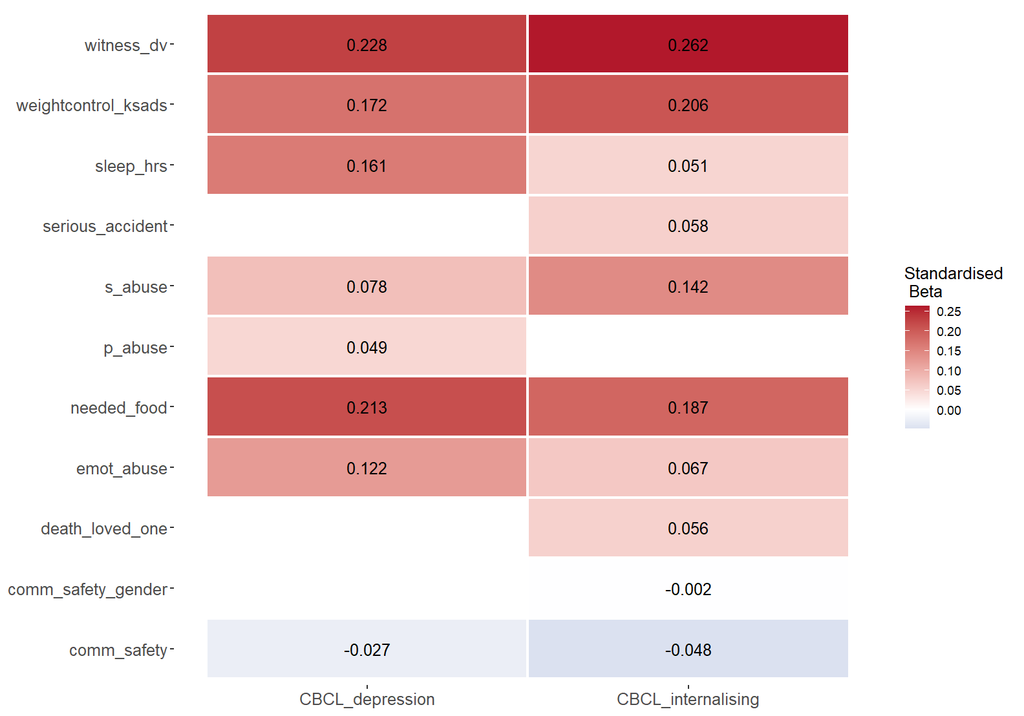

## Correlation plots

### Whole sample

NULL

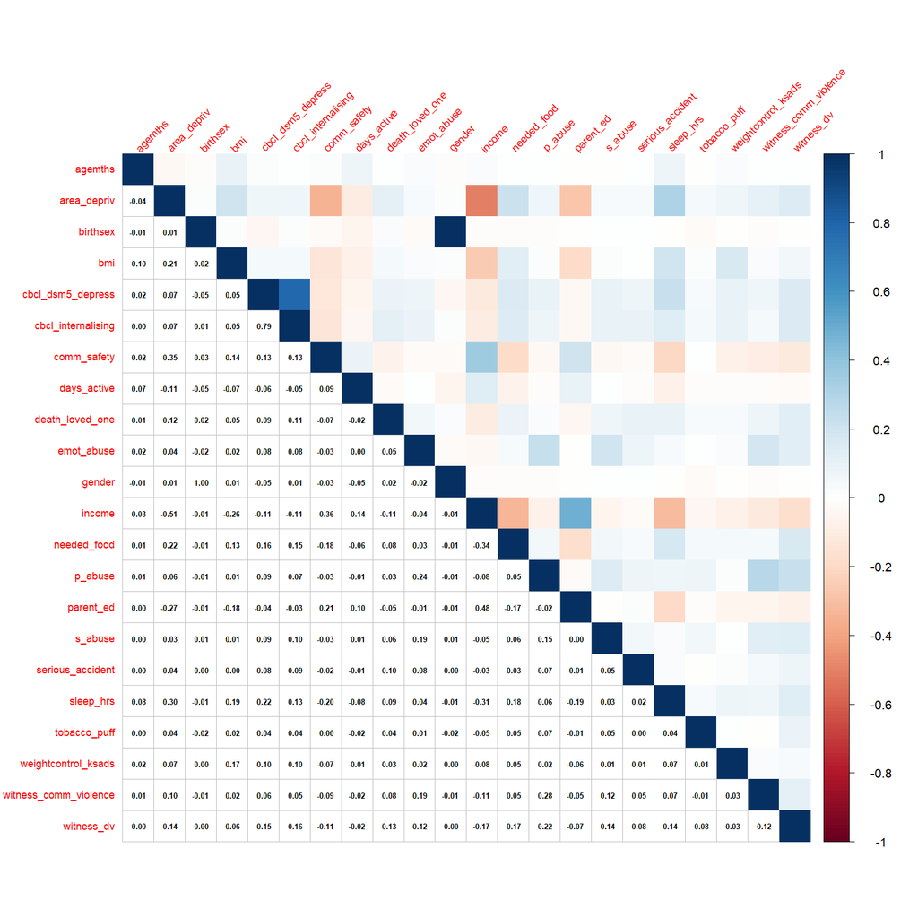

### Training sample

NULL

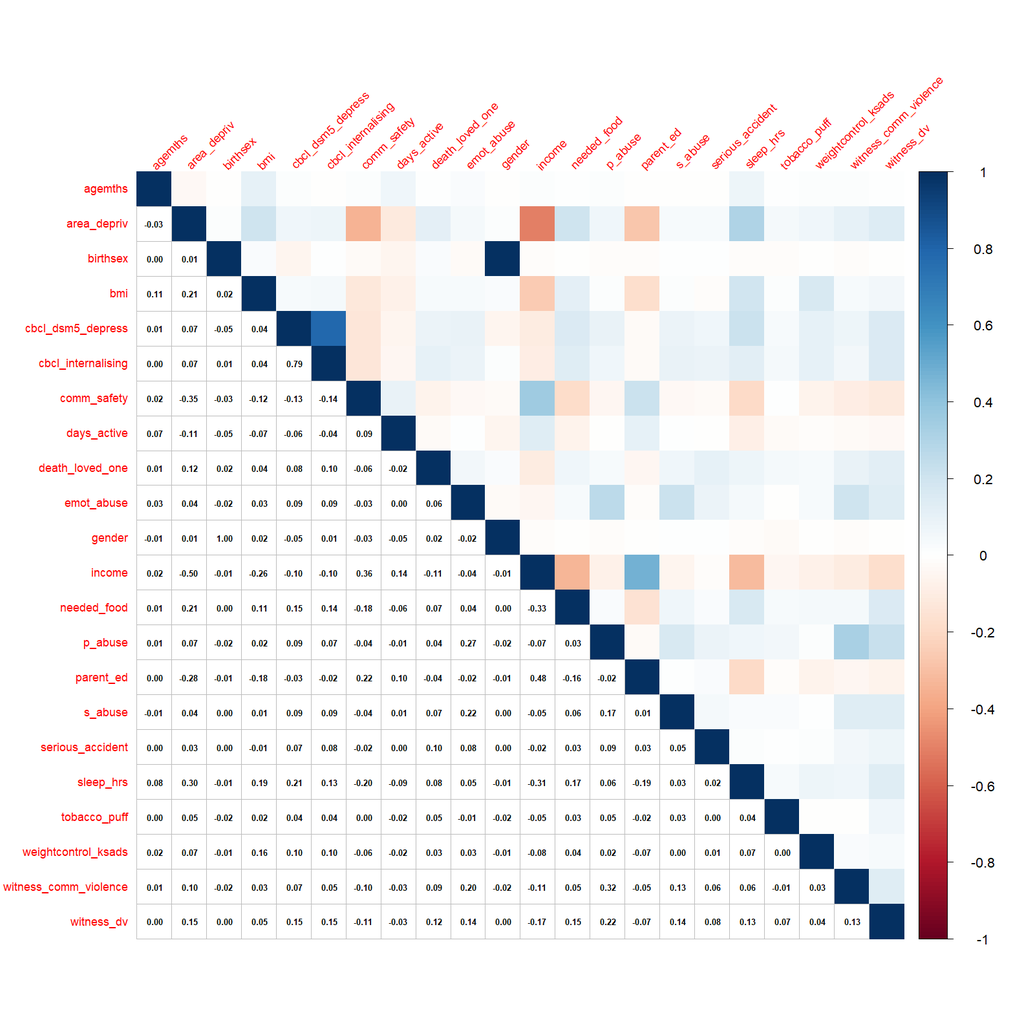

### Test sample

NULL

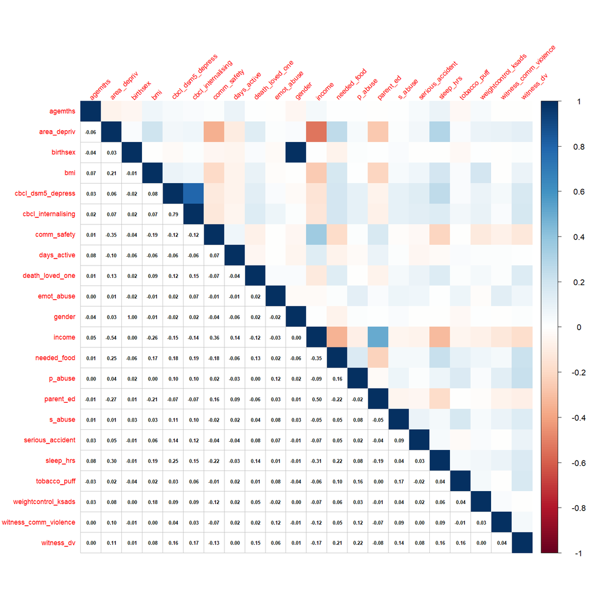

## Descriptives

### Whole sample

temporary images written to ‘C:’

Data Frame Summary

**Dimensions**: 7589 x 23  
**Duplicates**: 0

| **Variable** | **Stats / Values** | **Freqs (% of Valid)** | **Graph** | **Missing** |
| --- | --- | --- | --- | --- |
| tobacco_puff [factor] | 1. 0 2. 1 | 7535 ( 99.3% ) 54 ( 0.7% ) |  | 0 (0.0%) |
| weightcontrol_ksads [factor] | 1. 0 2. 1 | 7382 ( 97.3% ) 207 ( 2.7% ) |  | 0 (0.0%) |
| witness_comm_violence [factor] | 1. 0 2. 1 | 7521 ( 99.1% ) 68 ( 0.9% ) |  | 0 (0.0%) |
| death_loved_one [factor] | 1. 0 2. 1 | 5733 ( 75.5% ) 1856 ( 24.5% ) |  | 0 (0.0%) |
| witness_dv [factor] | 1. 0 2. 1 | 6977 ( 91.9% ) 612 ( 8.1% ) |  | 0 (0.0%) |
| s_abuse [factor] | 1. 0 2. 1 | 7433 ( 97.9% ) 156 ( 2.1% ) |  | 0 (0.0%) |
| p_abuse [factor] | 1. 0 2. 1 | 7517 ( 99.1% ) 72 ( 0.9% ) |  | 0 (0.0%) |
| emot_abuse [factor] | 1. 0 2. 1 | 7513 ( 99.0% ) 76 ( 1.0% ) |  | 0 (0.0%) |
| serious_accident [factor] | 1. 0 2. 1 | 6995 ( 92.2% ) 594 ( 7.8% ) |  | 0 (0.0%) |
| sleep_hrs [ordered, factor] | 1. 9+hrs 2. 8-9hrs 3. 7-8hrs 4. 5-7hrs 5. <5hrs | 3743 ( 49.3% ) 2750 ( 36.2% ) 868 ( 11.4% ) 208 ( 2.7% ) 20 ( 0.3% ) |  | 0 (0.0%) |
| bmi [numeric] | Mean (sd) : 18.7 (4.1) min ≤ med ≤ max: 9.8 ≤ 17.6 ≤ 53.9 IQR (CV) : 4.6 (0.2) | 5272 distinct values |  | 0 (0.0%) |
| needed_food [factor] | 1. 0 2. 1 | 7018 ( 92.5% ) 571 ( 7.5% ) |  | 0 (0.0%) |
| income [integer] | Mean (sd) : 7.3 (2.3) min ≤ med ≤ max: 1 ≤ 8 ≤ 10 IQR (CV) : 3 (0.3) | 1 : 239 ( 3.1% ) 2 : 279 ( 3.7% ) 3 : 182 ( 2.4% ) 4 : 331 ( 4.4% ) 5 : 443 ( 5.8% ) 6 : 655 ( 8.6% ) 7 : 1068 ( 14.1% ) 8 : 1129 ( 14.9% ) 9 : 2373 ( 31.3% ) 10 : 890 ( 11.7% ) |  | 0 (0.0%) |
| parent_ed [ordered, factor] | 1. 2. HS/GED 3. Some_College 4. Bachelor 5. Postgrad | 339 ( 4.5% ) 721 ( 9.5% ) 6013 ( 79.2% ) 234 ( 3.1% ) 282 ( 3.7% ) |  | 0 (0.0%) |
| birthsex [factor] | 1. M 2. F 3. Intersex | 4004 ( 52.8% ) 3585 ( 47.2% ) 0 ( 0.0% ) |  | 0 (0.0%) |
| gender [factor] | 1. M 2. F 3. GNC | 4001 ( 52.7% ) 3588 ( 47.3% ) 0 ( 0.0% ) |  | 0 (0.0%) |
| race_ethnicity [factor] | 1. White 2. Black 3. Hispanic 4. Asian 5. Other | 4217 ( 55.6% ) 964 ( 12.7% ) 1408 ( 18.6% ) 167 ( 2.2% ) 833 ( 11.0% ) |  | 0 (0.0%) |
| area_depriv [integer] | Mean (sd) : 38.9 (26.6) min ≤ med ≤ max: 1 ≤ 33 ≤ 100 IQR (CV) : 37 (0.7) | 100 distinct values |  | 0 (0.0%) |
| comm_safety [numeric] | Mean (sd) : 3.9 (0.9) min ≤ med ≤ max: 1 ≤ 4 ≤ 5 IQR (CV) : 1.3 (0.2) | 16 distinct values |  | 0 (0.0%) |
| days_active [integer] | Mean (sd) : 3.6 (2.3) min ≤ med ≤ max: 0 ≤ 3 ≤ 7 IQR (CV) : 3 (0.6) | 0 : 860 ( 11.3% ) 1 : 872 ( 11.5% ) 2 : 1024 ( 13.5% ) 3 : 1076 ( 14.2% ) 4 : 855 ( 11.3% ) 5 : 1050 ( 13.8% ) 6 : 558 ( 7.4% ) 7 : 1294 ( 17.1% ) |  | 0 (0.0%) |
| agemths [integer] | Mean (sd) : 118.9 (7.4) min ≤ med ≤ max: 107 ≤ 119 ≤ 132 IQR (CV) : 13 (0.1) | 26 distinct values |  | 0 (0.0%) |
| cbcl_internalising [integer] | Mean (sd) : 5.1 (5.5) min ≤ med ≤ max: 0 ≤ 3 ≤ 51 IQR (CV) : 6 (1.1) | 40 distinct values |  | 0 (0.0%) |
| cbcl_dsm5_depress [integer] | Mean (sd) : 1.3 (2) min ≤ med ≤ max: 0 ≤ 0 ≤ 17 IQR (CV) : 2 (1.6) | 18 distinct values |  | 0 (0.0%) |

Generated by summarytools 1.0.1 ([R](https://www.r-project.org/) version 4.4.1)  
2024-10-15

### Training sample

temporary images written to ‘C:’

Data Frame Summary

train

**Dimensions**: 6090 x 23  
**Duplicates**: 0

| **Variable** | **Stats / Values** | **Freqs (% of Valid)** | **Graph** | **Missing** |
| --- | --- | --- | --- | --- |
| tobacco_puff [factor] | 1. 0 2. 1 | 6045 ( 99.3% ) 45 ( 0.7% ) |  | 0 (0.0%) |
| weightcontrol_ksads [factor] | 1. 0 2. 1 | 5920 ( 97.2% ) 170 ( 2.8% ) |  | 0 (0.0%) |
| witness_comm_violence [factor] | 1. 0 2. 1 | 6036 ( 99.1% ) 54 ( 0.9% ) |  | 0 (0.0%) |
| death_loved_one [factor] | 1. 0 2. 1 | 4638 ( 76.2% ) 1452 ( 23.8% ) |  | 0 (0.0%) |
| witness_dv [factor] | 1. 0 2. 1 | 5607 ( 92.1% ) 483 ( 7.9% ) |  | 0 (0.0%) |
| s_abuse [factor] | 1. 0 2. 1 | 5964 ( 97.9% ) 126 ( 2.1% ) |  | 0 (0.0%) |
| p_abuse [factor] | 1. 0 2. 1 | 6034 ( 99.1% ) 56 ( 0.9% ) |  | 0 (0.0%) |
| emot_abuse [factor] | 1. 0 2. 1 | 6030 ( 99.0% ) 60 ( 1.0% ) |  | 0 (0.0%) |
| serious_accident [factor] | 1. 0 2. 1 | 5608 ( 92.1% ) 482 ( 7.9% ) |  | 0 (0.0%) |
| sleep_hrs [ordered, factor] | 1. 9+hrs 2. 8-9hrs 3. 7-8hrs 4. 5-7hrs 5. <5hrs | 3018 ( 49.6% ) 2206 ( 36.2% ) 692 ( 11.4% ) 158 ( 2.6% ) 16 ( 0.3% ) |  | 0 (0.0%) |
| bmi [numeric] | Mean (sd) : 18.7 (4.1) min ≤ med ≤ max: 9.8 ≤ 17.6 ≤ 53.9 IQR (CV) : 4.5 (0.2) | 4403 distinct values |  | 0 (0.0%) |
| needed_food [factor] | 1. 0 2. 1 | 5640 ( 92.6% ) 450 ( 7.4% ) |  | 0 (0.0%) |
| income [integer] | Mean (sd) : 7.3 (2.4) min ≤ med ≤ max: 1 ≤ 8 ≤ 10 IQR (CV) : 3 (0.3) | 1 : 203 ( 3.3% ) 2 : 222 ( 3.6% ) 3 : 144 ( 2.4% ) 4 : 254 ( 4.2% ) 5 : 350 ( 5.7% ) 6 : 526 ( 8.6% ) 7 : 859 ( 14.1% ) 8 : 903 ( 14.8% ) 9 : 1911 ( 31.4% ) 10 : 718 ( 11.8% ) |  | 0 (0.0%) |
| parent_ed [ordered, factor] | 1. 2. HS/GED 3. Some_College 4. Bachelor 5. Postgrad | 255 ( 4.2% ) 587 ( 9.6% ) 4817 ( 79.1% ) 204 ( 3.3% ) 227 ( 3.7% ) |  | 0 (0.0%) |
| birthsex [factor] | 1. M 2. F 3. Intersex | 3220 ( 52.9% ) 2870 ( 47.1% ) 0 ( 0.0% ) |  | 0 (0.0%) |
| gender [factor] | 1. M 2. F 3. GNC | 3218 ( 52.8% ) 2872 ( 47.2% ) 0 ( 0.0% ) |  | 0 (0.0%) |
| race_ethnicity [factor] | 1. White 2. Black 3. Hispanic 4. Asian 5. Other | 3396 ( 55.8% ) 758 ( 12.4% ) 1136 ( 18.7% ) 137 ( 2.2% ) 663 ( 10.9% ) |  | 0 (0.0%) |
| area_depriv [integer] | Mean (sd) : 38.7 (26.6) min ≤ med ≤ max: 1 ≤ 32 ≤ 100 IQR (CV) : 37 (0.7) | 100 distinct values |  | 0 (0.0%) |
| comm_safety [numeric] | Mean (sd) : 3.9 (0.9) min ≤ med ≤ max: 1 ≤ 4 ≤ 5 IQR (CV) : 1.3 (0.2) | 15 distinct values |  | 0 (0.0%) |
| days_active [integer] | Mean (sd) : 3.6 (2.3) min ≤ med ≤ max: 0 ≤ 3 ≤ 7 IQR (CV) : 3 (0.6) | 0 : 695 ( 11.4% ) 1 : 700 ( 11.5% ) 2 : 829 ( 13.6% ) 3 : 868 ( 14.3% ) 4 : 680 ( 11.2% ) 5 : 859 ( 14.1% ) 6 : 439 ( 7.2% ) 7 : 1020 ( 16.7% ) |  | 0 (0.0%) |
| agemths [integer] | Mean (sd) : 118.9 (7.4) min ≤ med ≤ max: 107 ≤ 119 ≤ 132 IQR (CV) : 13 (0.1) | 26 distinct values |  | 0 (0.0%) |
| cbcl_internalising [integer] | Mean (sd) : 5.1 (5.5) min ≤ med ≤ max: 0 ≤ 3 ≤ 51 IQR (CV) : 6 (1.1) | 40 distinct values |  | 0 (0.0%) |
| cbcl_dsm5_depress [integer] | Mean (sd) : 1.3 (2) min ≤ med ≤ max: 0 ≤ 0 ≤ 17 IQR (CV) : 2 (1.6) | 17 distinct values |  | 0 (0.0%) |

Generated by summarytools 1.0.1 ([R](https://www.r-project.org/) version 4.4.1)  
2024-10-15

### Test sample

temporary images written to ‘C:’

Data Frame Summary

test

**Dimensions**: 1499 x 23  
**Duplicates**: 0

| **Variable** | **Stats / Values** | **Freqs (% of Valid)** | **Graph** | **Missing** |
| --- | --- | --- | --- | --- |
| tobacco_puff [factor] | 1. 0 2. 1 | 1490 ( 99.4% ) 9 ( 0.6% ) |  | 0 (0.0%) |
| weightcontrol_ksads [factor] | 1. 0 2. 1 | 1462 ( 97.5% ) 37 ( 2.5% ) |  | 0 (0.0%) |
| witness_comm_violence [factor] | 1. 0 2. 1 | 1485 ( 99.1% ) 14 ( 0.9% ) |  | 0 (0.0%) |
| death_loved_one [factor] | 1. 0 2. 1 | 1095 ( 73.0% ) 404 ( 27.0% ) |  | 0 (0.0%) |
| witness_dv [factor] | 1. 0 2. 1 | 1370 ( 91.4% ) 129 ( 8.6% ) |  | 0 (0.0%) |
| s_abuse [factor] | 1. 0 2. 1 | 1469 ( 98.0% ) 30 ( 2.0% ) |  | 0 (0.0%) |
| p_abuse [factor] | 1. 0 2. 1 | 1483 ( 98.9% ) 16 ( 1.1% ) |  | 0 (0.0%) |
| emot_abuse [factor] | 1. 0 2. 1 | 1483 ( 98.9% ) 16 ( 1.1% ) |  | 0 (0.0%) |
| serious_accident [factor] | 1. 0 2. 1 | 1387 ( 92.5% ) 112 ( 7.5% ) |  | 0 (0.0%) |
| sleep_hrs [ordered, factor] | 1. 9+hrs 2. 8-9hrs 3. 7-8hrs 4. 5-7hrs 5. <5hrs | 725 ( 48.4% ) 544 ( 36.3% ) 176 ( 11.7% ) 50 ( 3.3% ) 4 ( 0.3% ) |  | 0 (0.0%) |
| bmi [numeric] | Mean (sd) : 18.9 (4.2) min ≤ med ≤ max: 10 ≤ 17.7 ≤ 42.3 IQR (CV) : 4.7 (0.2) | 1338 distinct values |  | 0 (0.0%) |
| needed_food [factor] | 1. 0 2. 1 | 1378 ( 91.9% ) 121 ( 8.1% ) |  | 0 (0.0%) |
| income [integer] | Mean (sd) : 7.3 (2.3) min ≤ med ≤ max: 1 ≤ 8 ≤ 10 IQR (CV) : 3 (0.3) | 1 : 36 ( 2.4% ) 2 : 57 ( 3.8% ) 3 : 38 ( 2.5% ) 4 : 77 ( 5.1% ) 5 : 93 ( 6.2% ) 6 : 129 ( 8.6% ) 7 : 209 ( 13.9% ) 8 : 226 ( 15.1% ) 9 : 462 ( 30.8% ) 10 : 172 ( 11.5% ) |  | 0 (0.0%) |
| parent_ed [ordered, factor] | 1. 2. HS/GED 3. Some_College 4. Bachelor 5. Postgrad | 84 ( 5.6% ) 134 ( 8.9% ) 1196 ( 79.8% ) 30 ( 2.0% ) 55 ( 3.7% ) |  | 0 (0.0%) |
| birthsex [factor] | 1. M 2. F 3. Intersex | 784 ( 52.3% ) 715 ( 47.7% ) 0 ( 0.0% ) |  | 0 (0.0%) |
| gender [factor] | 1. M 2. F 3. GNC | 783 ( 52.2% ) 716 ( 47.8% ) 0 ( 0.0% ) |  | 0 (0.0%) |
| race_ethnicity [factor] | 1. White 2. Black 3. Hispanic 4. Asian 5. Other | 821 ( 54.8% ) 206 ( 13.7% ) 272 ( 18.1% ) 30 ( 2.0% ) 170 ( 11.3% ) |  | 0 (0.0%) |
| area_depriv [integer] | Mean (sd) : 39.5 (26.7) min ≤ med ≤ max: 1 ≤ 34 ≤ 100 IQR (CV) : 38 (0.7) | 100 distinct values |  | 0 (0.0%) |
| comm_safety [numeric] | Mean (sd) : 3.9 (0.9) min ≤ med ≤ max: 1 ≤ 4 ≤ 5 IQR (CV) : 1.3 (0.2) | 14 distinct values |  | 0 (0.0%) |
| days_active [integer] | Mean (sd) : 3.7 (2.3) min ≤ med ≤ max: 0 ≤ 4 ≤ 7 IQR (CV) : 4 (0.6) | 0 : 165 ( 11.0% ) 1 : 172 ( 11.5% ) 2 : 195 ( 13.0% ) 3 : 208 ( 13.9% ) 4 : 175 ( 11.7% ) 5 : 191 ( 12.7% ) 6 : 119 ( 7.9% ) 7 : 274 ( 18.3% ) |  | 0 (0.0%) |
| agemths [integer] | Mean (sd) : 118.9 (7.5) min ≤ med ≤ max: 107 ≤ 119 ≤ 132 IQR (CV) : 13 (0.1) | 26 distinct values |  | 0 (0.0%) |
| cbcl_internalising [integer] | Mean (sd) : 5.2 (5.5) min ≤ med ≤ max: 0 ≤ 3 ≤ 31 IQR (CV) : 6 (1.1) | 32 distinct values |  | 0 (0.0%) |
| cbcl_dsm5_depress [integer] | Mean (sd) : 1.3 (2) min ≤ med ≤ max: 0 ≤ 0 ≤ 16 IQR (CV) : 2 (1.6) | 14 distinct values |  | 0 (0.0%) |

Generated by summarytools 1.0.1 ([R](https://www.r-project.org/) version 4.4.1)  
2024-10-15

# Sensitivity analyses using birthsex instead of gender

## CBCL DSM5-oriented depression subscale

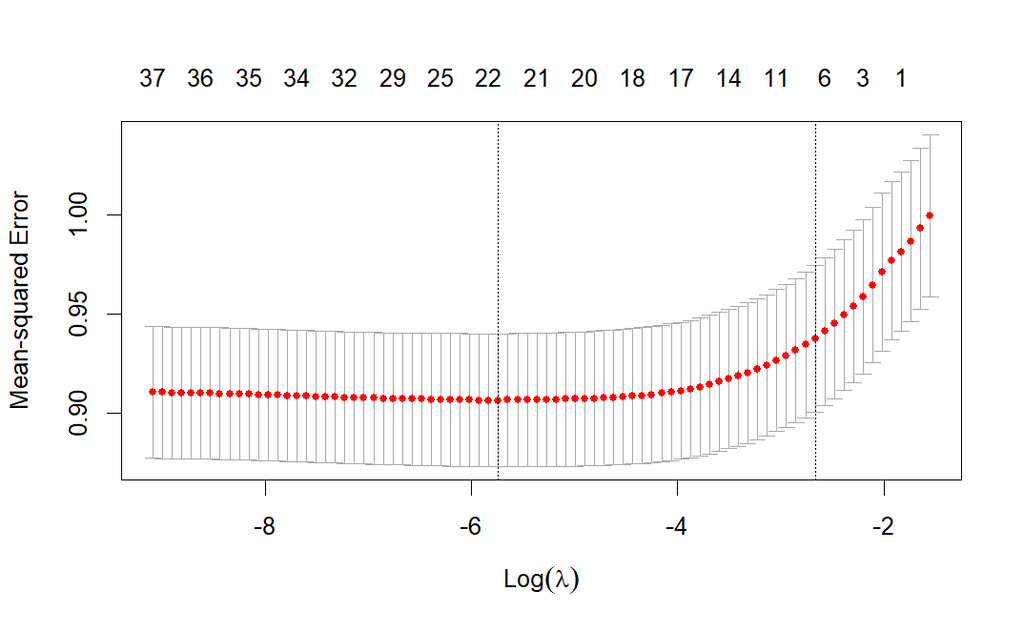

| Criteria | Lambda | MSE | SE | RMSE | Nonzero |
| --- | --- | --- | --- | --- | --- |
| min | 0.003 | 0.907 | 0.034 | 0.952 | 23 |
| 1se | 0.069 | 0.938 | 0.037 | 0.968 | 8 |

### Fit statistics

| Sample | Lambda | MSE | RMSE | MAE |
| --- | --- | --- | --- | --- |
| training | min | 0.896 | 0.947 | 0.665 |
| training | 1se | 0.934 | 0.966 | 0.676 |
| test | min | 0.888 | 0.942 | 0.656 |
| test | 1se | 0.888 | 0.942 | 0.656 |

### Plot predictions

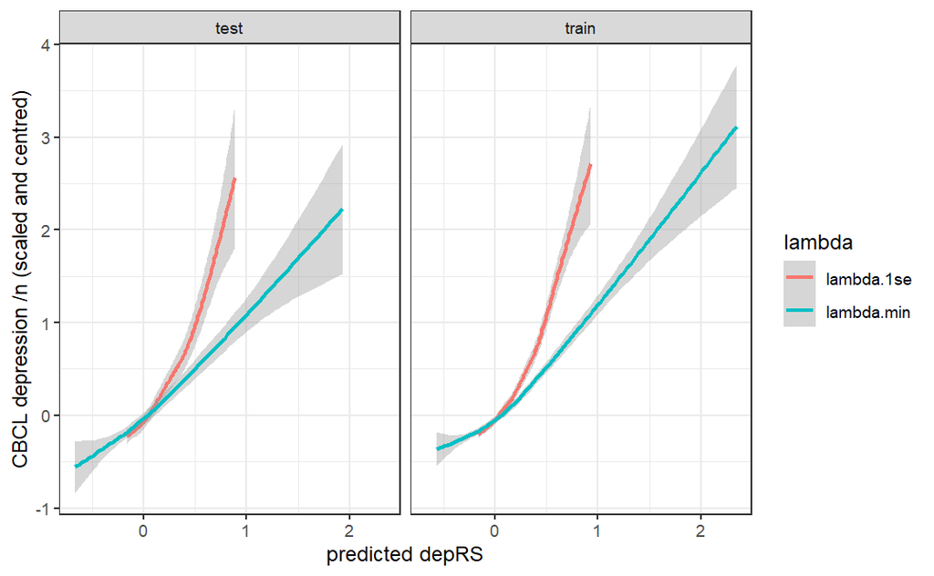

## CBCL internalising subscale

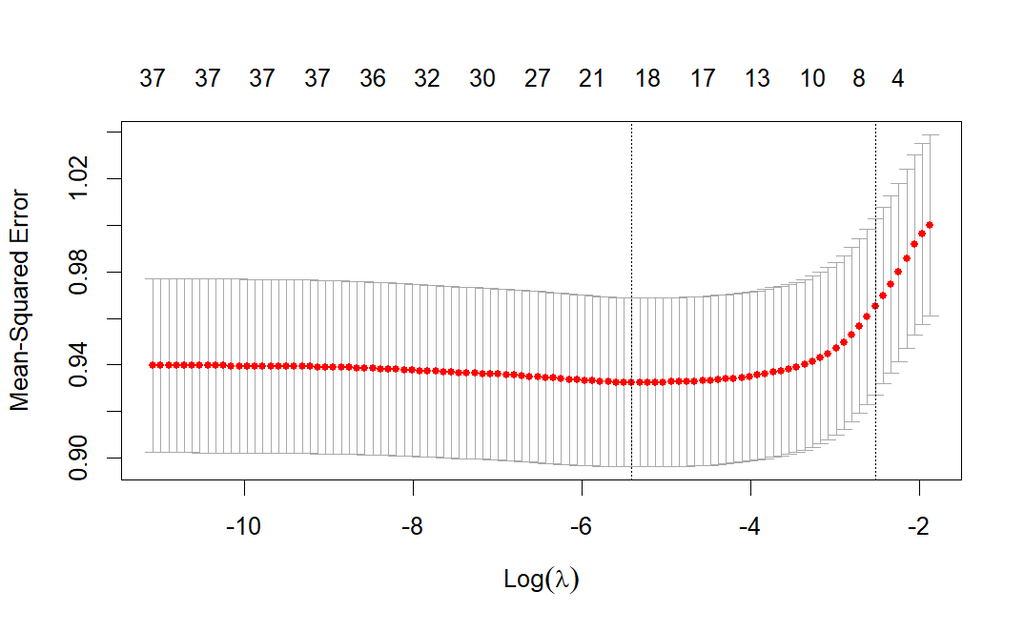

| Criteria | Lambda | MSE | SE | RMSE | Nonzero |
| --- | --- | --- | --- | --- | --- |
| min | 0.004 | 0.933 | 0.036 | 0.966 | 23 |
| 1se | 0.080 | 0.965 | 0.038 | 0.982 | 8 |

### Fit statistics

| Sample | Lambda | MSE | RMSE | MAE |
| --- | --- | --- | --- | --- |
| training | min | 0.922 | 0.960 | 0.708 |
| training | 1se | 0.961 | 0.980 | 0.721 |
| test | min | 0.899 | 0.948 | 0.660 |
| test | 1se | 0.899 | 0.948 | 0.660 |

### Plot predictions

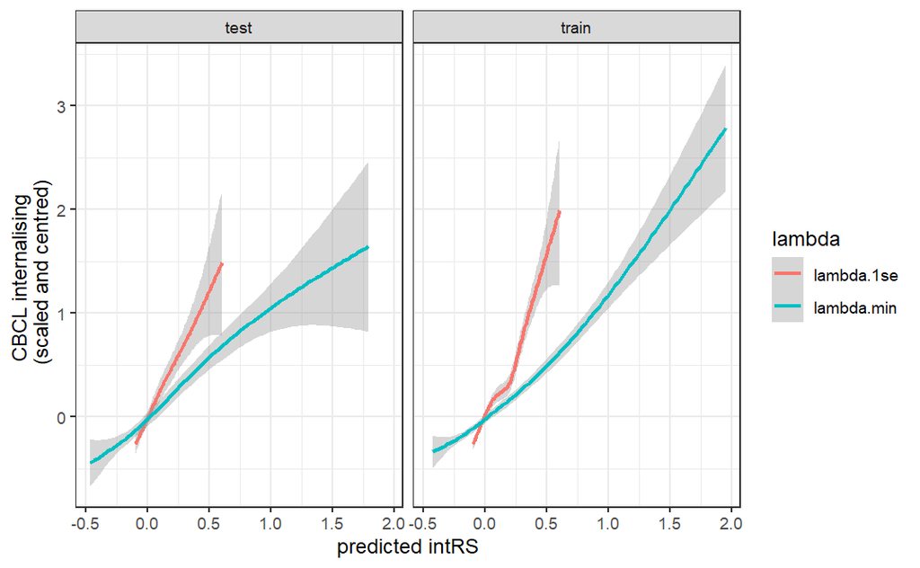

## Non-zero coefficients

beta.min = coefficients for lambda value that produces minimum mean cross-validated error beta.1se = coefficients for lambda value that produces the most regularized model while keeping the cross-validated error within one standard error of the minimum.

| predictor | dep_beta.min | dep_beta.1se | int_beta.min | int_beta.1se |
| --- | --- | --- | --- | --- |
| (Intercept) | -3.274 | -0.870 | -2.966 | -0.553 |
| tobacco_puff | 0.188 | 0.000 | 0.273 | 0.000 |
| weightcontrol_ksads | 0.478 | 0.111 | 0.458 | 0.080 |
| witness_comm_violence | 0.075 | 0.000 | 0.000 | 0.000 |
| death_loved_one | 0.089 | 0.000 | 0.135 | 0.017 |
| witness_dv | 0.303 | 0.207 | 0.341 | 0.218 |
| s_abuse | 0.300 | 0.023 | 0.364 | 0.014 |
| p_abuse | 0.325 | 0.000 | 0.057 | 0.000 |
| emot_abuse | 0.418 | 0.052 | 0.381 | 0.000 |
| serious_accident | 0.132 | 0.000 | 0.198 | 0.000 |
| sleep_hrs | 0.291 | 0.153 | 0.099 | 0.034 |
| bmi | -0.020 | 0.000 | 0.000 | 0.000 |
| needed_food | 0.368 | 0.186 | 0.318 | 0.133 |
| income | 0.000 | 0.000 | 0.000 | 0.000 |
| parent_ed | 0.052 | 0.000 | 0.044 | 0.000 |
| birthsex | 0.000 | 0.000 | 0.000 | 0.000 |
| area_depriv | 0.000 | 0.000 | 0.000 | 0.000 |
| comm_safety | -0.046 | -0.020 | -0.049 | -0.036 |
| days_active | -0.033 | 0.000 | -0.018 | 0.000 |
| agemths | 0.026 | 0.000 | 0.000 | 0.000 |
| tobacco_puff_sex | 0.000 | 0.000 | 0.000 | 0.000 |
| weightcontrol_ksads_sex | 0.002 | 0.000 | 0.013 | 0.000 |
| witness_comm_violence_sex | 0.000 | 0.000 | 0.000 | 0.000 |
| death_loved_one_sex | 0.000 | 0.000 | 0.000 | 0.000 |
| witness_dv_sex | 0.000 | 0.000 | 0.000 | 0.000 |
| s_abuse_sex | 0.000 | 0.000 | 0.000 | 0.000 |
| p_abuse_sex | 0.000 | 0.000 | 0.000 | 0.000 |
| emot_abuse_sex | -0.021 | 0.000 | 0.000 | 0.000 |
| serious_accident_sex | 0.000 | 0.000 | 0.000 | 0.000 |
| sleep_hrs_sex | -0.051 | 0.000 | 0.000 | 0.000 |
| bmi_sex | 0.000 | 0.000 | -0.001 | 0.000 |
| needed_food_sex | 0.000 | 0.000 | 0.000 | 0.000 |
| income_sex | 0.000 | 0.000 | 0.000 | 0.000 |
| parent_ed_sex | 0.000 | 0.000 | 0.000 | 0.000 |
| area_depriv_sex | -0.032 | 0.000 | -0.018 | 0.000 |
| comm_safety_sex | -0.021 | 0.000 | -0.028 | 0.000 |
| days_active_sex | 0.000 | 0.000 | 0.000 | 0.000 |
| agemths_sex | -0.020 | 0.000 | -0.007 | 0.000 |

### beta.min

|  | preds | beta.min | beta.1se | out |
| --- | --- | --- | --- | --- |
| 39 | weightcontrol_ksads | 0.4776050 | 0.1113368 | CBCL_depression |
| 3 | weightcontrol_ksads | 0.4581320 | 0.0797292 | CBCL_internalising |
| 91 | emot_abuse | 0.4175796 | 0.0519412 | CBCL_depression |
| 9 | emot_abuse | 0.3812562 | 0.0000000 | CBCL_internalising |
| 131 | needed_food | 0.3683883 | 0.1858114 | CBCL_depression |
| 7 | s_abuse | 0.3639285 | 0.0141927 | CBCL_internalising |
| 6 | witness_dv | 0.3409999 | 0.2184757 | CBCL_internalising |
| 81 | p_abuse | 0.3249719 | 0.0000000 | CBCL_depression |
| 13 | needed_food | 0.3181509 | 0.1330762 | CBCL_internalising |
| 61 | witness_dv | 0.3029090 | 0.2072138 | CBCL_depression |
| 71 | s_abuse | 0.2996664 | 0.0230763 | CBCL_depression |
| 111 | sleep_hrs | 0.2910158 | 0.1527343 | CBCL_depression |
| 2 | tobacco_puff | 0.2727024 | 0.0000000 | CBCL_internalising |
| 10 | serious_accident | 0.1975388 | 0.0000000 | CBCL_internalising |
| 210 | tobacco_puff | 0.1875056 | 0.0000000 | CBCL_depression |
| 5 | death_loved_one | 0.1354183 | 0.0170111 | CBCL_internalising |
| 101 | serious_accident | 0.1319638 | 0.0000000 | CBCL_depression |
| 11 | sleep_hrs | 0.0987391 | 0.0336040 | CBCL_internalising |
| 51 | death_loved_one | 0.0888262 | 0.0000000 | CBCL_depression |
| 41 | witness_comm_violence | 0.0751986 | 0.0000000 | CBCL_depression |
| 8 | p_abuse | 0.0573042 | 0.0000000 | CBCL_internalising |
| 151 | parent_ed | 0.0522453 | 0.0000000 | CBCL_depression |
| 15 | parent_ed | 0.0444352 | 0.0000000 | CBCL_internalising |
| 201 | agemths | 0.0261121 | 0.0000000 | CBCL_depression |
| 22 | weightcontrol_ksads_sex | 0.0131743 | 0.0000000 | CBCL_internalising |
| 221 | weightcontrol_ksads_sex | 0.0018306 | 0.0000000 | CBCL_depression |
| 31 | bmi_sex | -0.0011565 | 0.0000000 | CBCL_internalising |
| 38 | agemths_sex | -0.0065140 | 0.0000000 | CBCL_internalising |
| 35 | area_depriv_sex | -0.0180615 | 0.0000000 | CBCL_internalising |
| 19 | days_active | -0.0183912 | 0.0000000 | CBCL_internalising |
| 121 | bmi | -0.0197216 | 0.0000000 | CBCL_depression |
| 381 | agemths_sex | -0.0203205 | 0.0000000 | CBCL_depression |
| 361 | comm_safety_sex | -0.0205965 | 0.0000000 | CBCL_depression |
| 281 | emot_abuse_sex | -0.0213406 | 0.0000000 | CBCL_depression |
| 36 | comm_safety_sex | -0.0280847 | 0.0000000 | CBCL_internalising |
| 351 | area_depriv_sex | -0.0315362 | 0.0000000 | CBCL_depression |
| 191 | days_active | -0.0333446 | 0.0000000 | CBCL_depression |
| 181 | comm_safety | -0.0460103 | -0.0200139 | CBCL_depression |
| 18 | comm_safety | -0.0490189 | -0.0355704 | CBCL_internalising |
| 301 | sleep_hrs_sex | -0.0505731 | 0.0000000 | CBCL_depression |

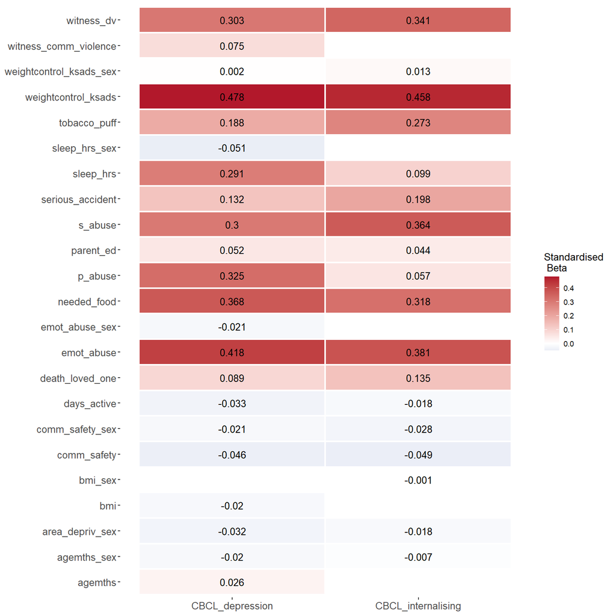

### beta.1se

|  | preds | beta.min | beta.1se | out |
| --- | --- | --- | --- | --- |
| 6 | witness_dv | 0.3409999 | 0.2184757 | CBCL_internalising |
| 61 | witness_dv | 0.3029090 | 0.2072138 | CBCL_depression |
| 131 | needed_food | 0.3683883 | 0.1858114 | CBCL_depression |
| 111 | sleep_hrs | 0.2910158 | 0.1527343 | CBCL_depression |
| 13 | needed_food | 0.3181509 | 0.1330762 | CBCL_internalising |
| 39 | weightcontrol_ksads | 0.4776050 | 0.1113368 | CBCL_depression |
| 3 | weightcontrol_ksads | 0.4581320 | 0.0797292 | CBCL_internalising |
| 91 | emot_abuse | 0.4175796 | 0.0519412 | CBCL_depression |
| 11 | sleep_hrs | 0.0987391 | 0.0336040 | CBCL_internalising |
| 71 | s_abuse | 0.2996664 | 0.0230763 | CBCL_depression |
| 5 | death_loved_one | 0.1354183 | 0.0170111 | CBCL_internalising |
| 7 | s_abuse | 0.3639285 | 0.0141927 | CBCL_internalising |
| 181 | comm_safety | -0.0460103 | -0.0200139 | CBCL_depression |
| 18 | comm_safety | -0.0490189 | -0.0355704 | CBCL_internalising |

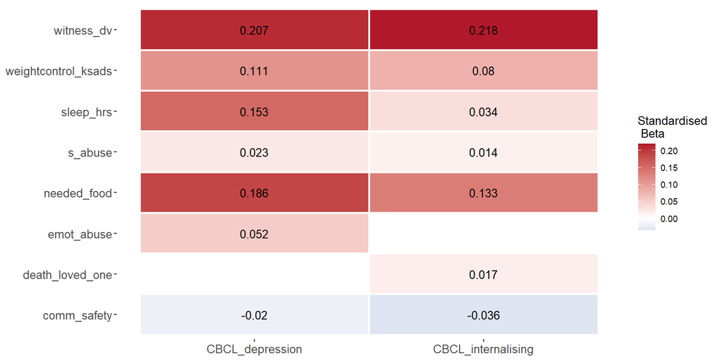